# Practical Machine Learning Assignment

Prabeeti Bulani

10/11/2019

# 1. Background

Using devices such as Jawbone Up, Nike FuelBand, and Fitbit it is now possible to collect a large amount of data about personal activity relatively inexpensively. These type of devices are part of the quantified self movement – a group of enthusiasts who take measurements about themselves regularly to improve their health, to find patterns in their behavior, or because they are tech geeks. One thing that people regularly do is quantify how much of a particular activity they do, but they rarely quantify how well they do it.

# 2. Objective

In this project, my objective is to use data from accelerometers on the belt, forearm, arm, and dumbell of 6 participants and predict the manner in which these particiapnts have prerformed these exercises. They were asked to perform barbell lifts correctly and incorrectly in 5 different ways. #Data Source & References:- #http://web.archive.org/web/20161224072740/http:/groupware.les.inf.puc-rio.br/har #(refer-Weight Lifting Exercise Data) #Training data - https://d396qusza40orc.cloudfront.net/predmachlearn/pml-training.csv #Test Set-https://d396qusza40orc.cloudfront.net/predmachlearn/pml-testing.csv

# 3. Data Loading and Exploratory Analysis

```r
# Following library are used
library(knitr)
library(caret)
```

```r
library(rpart)
library(rpart.plot)
library(rattle)
library(randomForest)
library(corrplot)
library(janitor)
set.seed(123)
# Data Extraction
Training_url <- "https://d396qusza40orc.cloudfront.net/predmachlearn/pml-training.csv"
Testing_url  <- "https://d396qusza40orc.cloudfront.net/predmachlearn/pml-testing.csv"
Training_data<-"pml-traininig.csv"
Testing_data<-"pml-testing.csv"

if(!file.exists(Training_data))
{
    download.file(Training_url,destfile = Training_data,method="curl")
}
training <- read.csv(Training_data, header = TRUE, sep = ",", na.strings=c("NA","#DIV/0!",""))
dim(training)
```

```
## [1] 19622   160
```

```r
if(!file.exists(Testing_data))
{
    download.file(Testing_url,destfile = Testing_data,method="curl")
}
testing  <- read.csv(Testing_data, header = TRUE, sep = ",", na.strings=c("NA","#DIV/0!",""))
dim(testing)
```

```
## [1]  20 160
```

```r
# create a partition using caret with the training dataset on 60,40 ratio
inTraining  <- createDataPartition(training$classe, p=0.6, list=FALSE)

Training_dataset <- training[inTraining, ]

Test_dataset  <- training[-inTraining, ]
# Exploring the data in training and test data
dim(Training_dataset)
```

```
## [1] 11776   160
```

```r
dim(Test_dataset)
```

```
## [1] 7846  160
```

```r
# Training and testing dataset both have 160 variables, with records count divided as 60:40 ratio
str(Training_dataset)
```

```
## 'data.frame':    11776 obs. of  160 variables:
##  $ X                       : int  1 2 5 7 12 13 17 18 19 20 ...
##  $ user_name               : Factor w/ 6 levels "adelmo","carlitos",..: 2 2 2 2 2 2 2 2 2 2 ...
##  $ raw_timestamp_part_1    : int  1323084231 1323084231 1323084232 1323084232 1323084232 1323084232 1323084232 1323084232 1323084232 1323084232 ...
##  $ raw_timestamp_part_2    : int  788290 808298 196328 368296 528316 560359 692324 732306 740353 788335 ...
##  $ cvtd_timestamp          : Factor w/ 20 levels "02/12/2011 13:32",..: 9 9 9 9 9 9 9 9 9 9 ...
##  $ new_window              : Factor w/ 2 levels "no","yes": 1 1 1 1 1 1 1 1 1 1 ...
##  $ num_window              : int  11 11 12 12 12 12 12 12 12 12 ...
##  $ roll_belt               : num  1.41 1.41 1.48 1.42 1.43 1.42 1.51 1.55 1.57 1.59 ...
##  $ pitch_belt              : num  8.07 8.07 8.07 8.09 8.18 8.2 8.12 8.08 8.06 8.07 ...
##  $ yaw_belt                : num  -94.4 -94.4 -94.4 -94.4 -94.4 -94.4 -94.4 -94.4 -94.4 -94.4 ...
##  $ total_accel_belt        : int  3 3 3 3 3 3 3 3 3 3 ...
##  $ kurtosis_roll_belt      : num  NA NA NA NA NA NA NA NA NA NA ...
##  $ kurtosis_picth_belt     : num  NA NA NA NA NA NA NA NA NA NA ...
##  $ kurtosis_yaw_belt       : logi  NA NA NA NA NA NA ...
```

[output cut: 86 more lines]

```r
# Data cleansing - cleaning the data for NA, The Near Zero variance (NZV) and ID variables
Training_nearZeroVar <- nearZeroVar(Training_dataset)
Training_dataset <- Training_dataset[, -Training_nearZeroVar]
Test_nearZeroVar <- nearZeroVar(Test_dataset)
Test_dataset  <- Test_dataset[, -Test_nearZeroVar]
label <- apply(Training_dataset, 2, function(x) mean(is.na(x))) > 0.95
Training_dataset <- Training_dataset[, -which(label, label == FALSE)]
label_test <- apply(Test_dataset, 2, function(x) mean(is.na(x))) > 0.95
Test_dataset <- Test_dataset[, -which(label_test, label_test == FALSE)]


Training_dataset <- Training_dataset[ , -(1:5)]
Test_dataset <- Test_dataset[ , -(1:5)]

dim(Training_dataset)
```

```
## [1] 11776    54
```

```r
dim(Test_dataset)
```

```
## [1] 7846   54
```

```r
# Training and testing dataset  have 54 and 54  variables respectively after cleansing.
```

# 4.Predictive Modelling Processes

# 4.1 Decision Tree Model

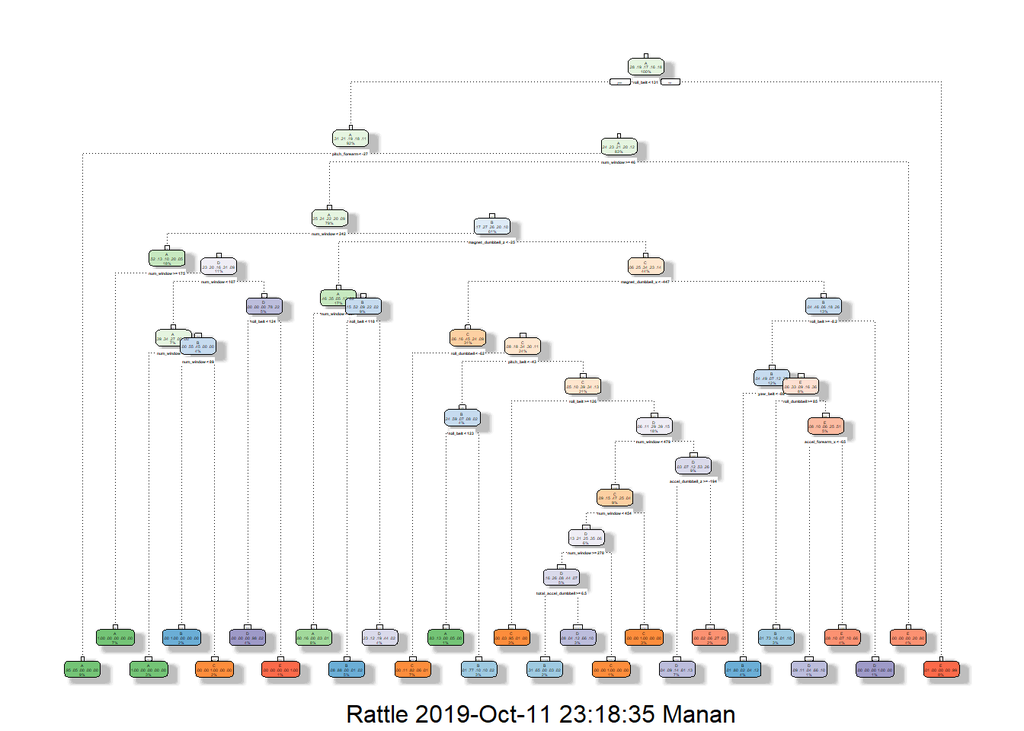

```r
# DEcision tree build
set.seed(123)
model_decisionTree <- rpart(classe ~ ., Training_dataset, method="class")
fancyRpartPlot(model_decisionTree)
```

```r
# Prediction with decision tree model
predict_DT<- predict(model_decisionTree, Test_dataset, type = "class")
confusionMatrix_DT <-confusionMatrix(predict_DT, Test_dataset$classe)
confusionMatrix_DT
```

```
## Confusion Matrix and Statistics
##
##           Reference
## Prediction    A    B    C    D    E
##          A 1955  122    3   25    8
##          B  124 1147   59   43   80
##          C    0   76 1100   39    4
##          D  134  130  177 1052  109
##          E   19   43   29  127 1241
##
## Overall Statistics
##
##                Accuracy : 0.8278
##                  95% CI : (0.8193, 0.8361)
##     No Information Rate : 0.2845
##     P-Value [Acc > NIR] : < 2.2e-16
##
##                   Kappa : 0.7828
##
##  Mcnemar's Test P-Value : < 2.2e-16
##
## Statistics by Class:
##
##                      Class: A Class: B Class: C Class: D Class: E
## Sensitivity            0.8759   0.7556   0.8041   0.8180   0.8606
## Specificity            0.9719   0.9516   0.9816   0.9162   0.9660
## Pos Pred Value         0.9252   0.7894   0.9024   0.6567   0.8506
## Neg Pred Value         0.9517   0.9420   0.9596   0.9625   0.9685
## Prevalence             0.2845   0.1935   0.1744   0.1639   0.1838
## Detection Rate         0.2492   0.1462   0.1402   0.1341   0.1582
## Detection Prevalence   0.2693   0.1852   0.1554   0.2042   0.1860
## Balanced Accuracy      0.9239   0.8536   0.8929   0.8671   0.9133
```

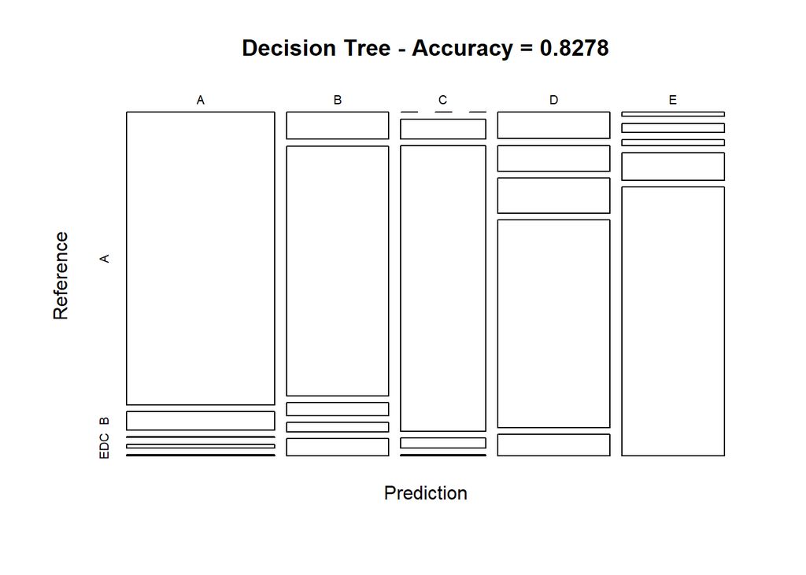

```r
# plot confusion matrix results
plot(confusionMatrix_DT$table, col = confusionMatrix_DT$byClass,
     main = paste("Decision Tree - Accuracy =",
                  round(confusionMatrix_DT$overall['Accuracy'], 4)))
```

# 4.2 Randon Forest Model

```r
# Random Forest build
set.seed(123)
train_ctrl <-  trainControl(method = "cv", classProbs=TRUE,savePredictions=TRUE,allowParallel=TRUE, number = 10)
model_randomForest <- randomForest(classe ~ ., data = Training_dataset, method = "rf", importance = T, trControl = train_ctrl,na.action = na.exclude)


# Prediction with random forest model
predict_RF<- predict(model_randomForest, Test_dataset, type = "class")
confusionMatrix_RF <-confusionMatrix(predict_RF, Test_dataset$classe)
confusionMatrix_RF
```

```
## Confusion Matrix and Statistics
##
##           Reference
## Prediction    A    B    C    D    E
##          A 2231    2    0    0    0
##          B    0 1515   11    0    0
##          C    0    1 1357   11    0
##          D    0    0    0 1274    2
##          E    1    0    0    1 1440
##
## Overall Statistics
##
##                Accuracy : 0.9963
##                  95% CI : (0.9947, 0.9975)
##     No Information Rate : 0.2845
##     P-Value [Acc > NIR] : < 2.2e-16
##
##                   Kappa : 0.9953
##
##  Mcnemar's Test P-Value : NA
##
## Statistics by Class:
##
##                      Class: A Class: B Class: C Class: D Class: E
## Sensitivity            0.9996   0.9980   0.9920   0.9907   0.9986
## Specificity            0.9996   0.9983   0.9981   0.9997   0.9997
## Pos Pred Value         0.9991   0.9928   0.9912   0.9984   0.9986
## Neg Pred Value         0.9998   0.9995   0.9983   0.9982   0.9997
## Prevalence             0.2845   0.1935   0.1744   0.1639   0.1838
## Detection Rate         0.2843   0.1931   0.1730   0.1624   0.1835
## Detection Prevalence   0.2846   0.1945   0.1745   0.1626   0.1838
## Balanced Accuracy      0.9996   0.9981   0.9951   0.9952   0.9992
```

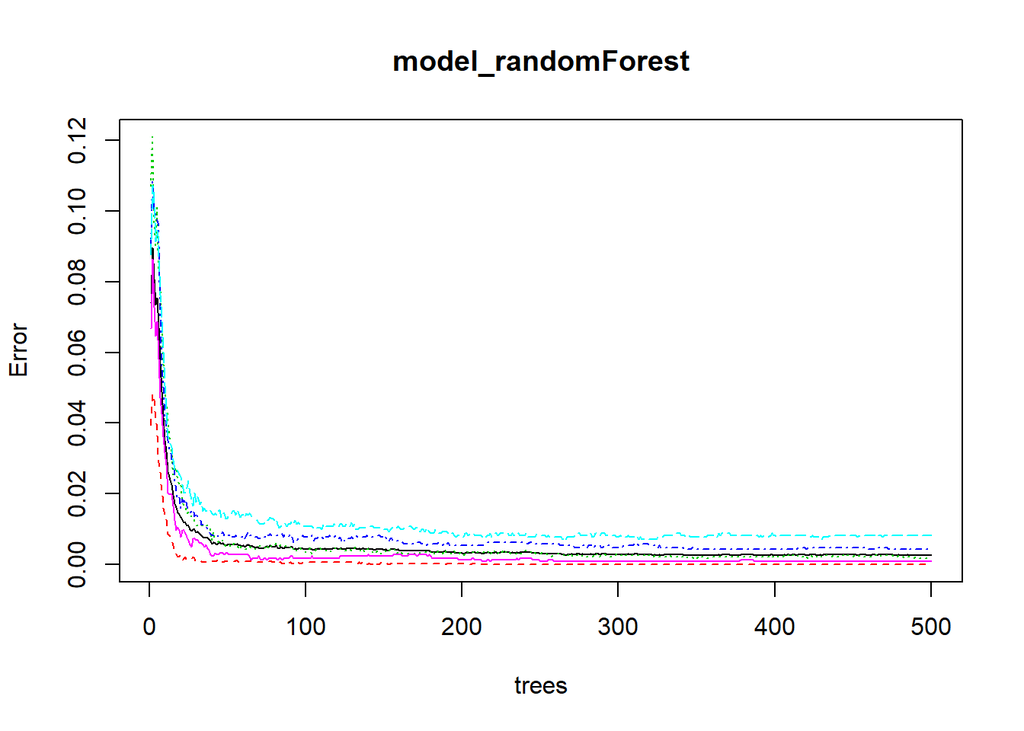

```r
# plot confusion matrix results for random forest
plot(model_randomForest)
```

# 4.3 Generalised Boosting Model

```r
# Generalised Boosting Model  build
set.seed(123)
gbm_control <- trainControl(method = "repeatedcv", number = 5, repeats =1,verboseIter = FALSE)
model_Boosting <- train(classe ~ ., method = "gbm",data= Training_dataset,
                    verbose = FALSE,
                    trControl = gbm_control)

model_Boosting
```

```
## Stochastic Gradient Boosting
##
## 11776 samples
##    53 predictor
##     5 classes: 'A', 'B', 'C', 'D', 'E'
##
## No pre-processing
## Resampling: Cross-Validated (5 fold, repeated 1 times)
## Summary of sample sizes: 9420, 9421, 9420, 9421, 9422
## Resampling results across tuning parameters:
##
##   interaction.depth  n.trees  Accuracy   Kappa
##   1                   50      0.7572160  0.6919090
##   1                  100      0.8325396  0.7880080
##   1                  150      0.8694789  0.8348284
##   2                   50      0.8828099  0.8516050
##   2                  100      0.9369047  0.9201733
##   2                  150      0.9617859  0.9516436
##   3                   50      0.9290921  0.9102227
##   3                  100      0.9700235  0.9620708
##   3                  150      0.9864979  0.9829213
##
## Tuning parameter 'shrinkage' was held constant at a value of 0.1
##
## Tuning parameter 'n.minobsinnode' was held constant at a value of 10
## Accuracy was used to select the optimal model using the largest value.
## The final values used for the model were n.trees = 150,
##  interaction.depth = 3, shrinkage = 0.1 and n.minobsinnode = 10.
```

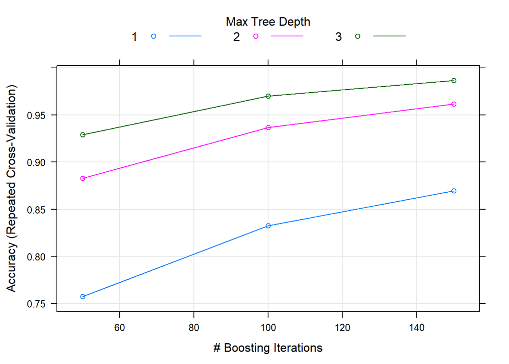

```r
plot(model_Boosting)
```

```r
# Prediction with Generalised Boosting Model model
predict_GBM<- predict(model_Boosting, Test_dataset)
confusionMatrix_GBM <-confusionMatrix(predict_GBM, Test_dataset$classe)
confusionMatrix_GBM
```

```
## Confusion Matrix and Statistics
##
##           Reference
## Prediction    A    B    C    D    E
##          A 2227   16    0    1    1
##          B    5 1481   14    5    4
##          C    0   16 1349   14    8
##          D    0    5    5 1262   10
##          E    0    0    0    4 1419
##
## Overall Statistics
##
##                Accuracy : 0.9862
##                  95% CI : (0.9834, 0.9887)
##     No Information Rate : 0.2845
##     P-Value [Acc > NIR] : < 2.2e-16
##
##                   Kappa : 0.9826
##
##  Mcnemar's Test P-Value : NA
##
## Statistics by Class:
##
##                      Class: A Class: B Class: C Class: D Class: E
## Sensitivity            0.9978   0.9756   0.9861   0.9813   0.9840
## Specificity            0.9968   0.9956   0.9941   0.9970   0.9994
## Pos Pred Value         0.9920   0.9814   0.9726   0.9844   0.9972
## Neg Pred Value         0.9991   0.9942   0.9971   0.9963   0.9964
## Prevalence             0.2845   0.1935   0.1744   0.1639   0.1838
## Detection Rate         0.2838   0.1888   0.1719   0.1608   0.1809
## Detection Prevalence   0.2861   0.1923   0.1768   0.1634   0.1814
## Balanced Accuracy      0.9973   0.9856   0.9901   0.9891   0.9917
```

# Conclusion

#Accuracy obtained from 3 models are as below:- #1. Decision Tree Model -0.8278 #2. Random Forest Model - 0.9963 #3. Boosting Model - 0.9862

Out of these, accuracy is best for random forest model , so Random Forest model is applied to predict the 20 quiz results

```r
predict_RF<- predict(model_randomForest, testing)
predict_RF
```

```
##  1  2  3  4  5  6  7  8  9 10 11 12 13 14 15 16 17 18 19 20
##  B  A  B  A  A  E  D  B  A  A  B  C  B  A  E  E  A  B  B  B
## Levels: A B C D E
```

I have used assumption in processing data is to limit dataset for attributes that are non-zero in the Training and tEsting dataset. I haved faced lots of error about missing attributes in Testing data but available in Training dataset but this got tackeled by using this assumption.